# Pique Dame - Die Hamburgische Staatsoper

[Die Hamburgische Staatsoper](https://www.die-hamburgische-staatsoper.de/de)

[figure not shown]

**© ×**

Thilo Beu

[Programm](https://www.die-hamburgische-staatsoper.de/de/programm/) → Oper

# Pique Dame

Peter Tschaikowsky

Inszenierung von 2003

- Sa 7.2. 19:00 Tickets
- Mi 18.2. 18:30 Tickets
- So 1.3. 16:00 Tickets
- Zum letzten Mal in dieser Spielzeit

  Fr 13.3. 19:00 Tickets

Sind wir frei, zu lieben, wen wir begehren? Der mittellose Hermann verfällt Lisa, einer Frau der Sankt Petersburger Elite. Zunehmend zerrissen zwischen Spielsucht und obsessiver Liebe, taumelt er auf den Abgrund zu. Inmitten von Tschaikowskys bombastischen Chorszenen fokussiert Willy Decker in seiner Inszenierung das finstere Seelenleben des Protagonisten – ein an sozialen Zwängen leidendes, schließlich zersplitterndes Ich.

## „Die saugende Präsenz des Spielsaales kann man sich kaum hypnotischer in Ihrer Anziehung vorstellen als mit Deckers und Gussmanns Bühnenspiel.“ DER SPIEGEL

Oper in drei Akten  
Komposition: Peter Tschaikowsky  
Libretto: Modest Tschaikowsky nach der gleichnamigen Erzählung von Alexander Puschkin

- 1890 19. Dezember, Uraufführung am Mariinsky-Theater in St. Petersburg
- 2003 25. Mai, Premiere dieser Inszenierung an der Hamburgischen Staatsoper
- 2026 Nach der letzten Vorstellung findet das Gespräch „Die Welt da draußen: Sucht und sozialer Abstieg“ zwischen Christopher Warmuth, Christine Tügel und Jörg Böckem statt.  
  13. März, nach der Vorstellung · Foyer 2. Rang

[figure not shown]

- **© ×**

  Beu

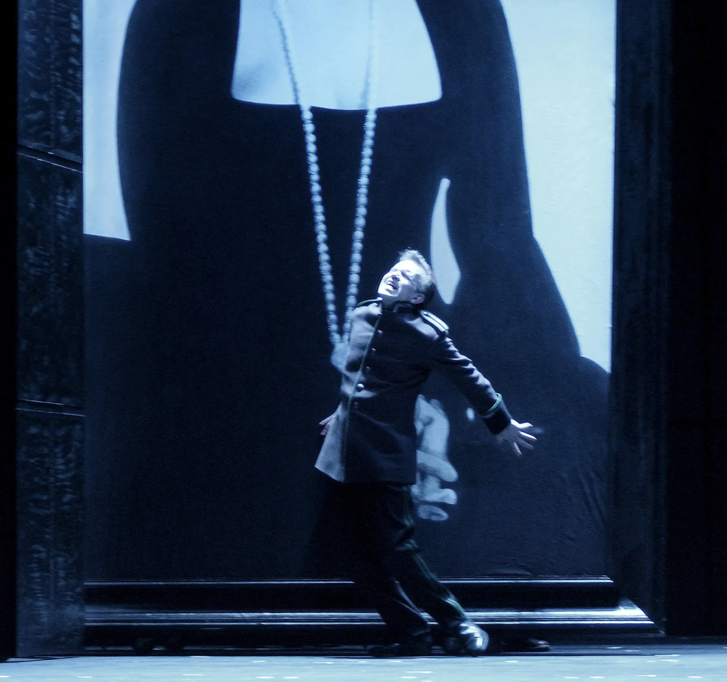

- **© ×**

  Beu

[figure not shown]

- **© ×**

  Beu

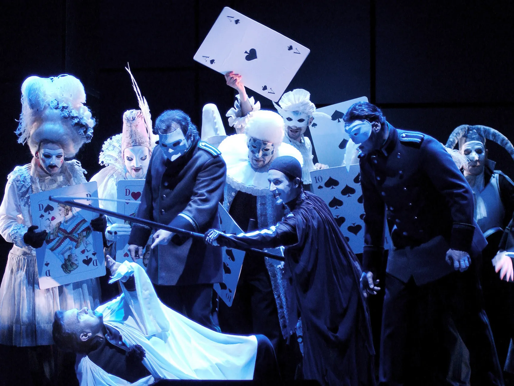

- **© ×**

  Beu

[figure not shown]

- **© ×**

  Beu

[figure not shown]

- **© ×**

  Beu

[figure not shown]

- **© ×**

  Beu

[figure not shown]

- **© ×**

  Beu

## Besetzung

- Musikalische Leitung

  [Timur Zangiev](https://www.die-hamburgische-staatsoper.de/de/personen/39916016-timur-zangiev)
- Inszenierung

  [Willy Decker](https://www.die-hamburgische-staatsoper.de/de/personen/768-willy-decker)
- Bühne

  [Wolfgang Gussmann](https://www.die-hamburgische-staatsoper.de/de/personen/710-wolfgang-gussmann)
- Kostüme

  [Wolfgang Gussmann](https://www.die-hamburgische-staatsoper.de/de/personen/710-wolfgang-gussmann)
- Licht

  [Hans Toelstede](https://www.die-hamburgische-staatsoper.de/de/personen/1083-hans-toelstede)
- Chor

  [Christian Günther](https://www.die-hamburgische-staatsoper.de/de/personen/5134-christian-guenther)
- Herman

  [Najmiddin Mavlyanov](https://www.die-hamburgische-staatsoper.de/de/personen/39913194-najmiddin-mavlyanov)
- Graf Tomsky

  [Łukasz Golinski](https://www.die-hamburgische-staatsoper.de/de/personen/39914586-lukasz-golinski)
- Fürst Jeletzky

  [Kartal Karagedik](https://www.die-hamburgische-staatsoper.de/de/personen/39912257-kartal-karagedik)
- Czekalinsky

  [Jürgen Sacher](https://www.die-hamburgische-staatsoper.de/de/personen/621-juergen-sacher)
- Ssurin

  [Hubert Kowalczyk](https://www.die-hamburgische-staatsoper.de/de/personen/39913534-hubert-kowalczyk)
- Tschaplitzky

  [Mziwamadoda Sipho Nodlayiya](https://www.die-hamburgische-staatsoper.de/de/personen/39915890-mziwamadoda-sipho-nodlayiya)
- Narumoff

  [Keith Klein](https://www.die-hamburgische-staatsoper.de/de/personen/39915892-keith-klein)
- Gräfin

  [Doris Soffel](https://www.die-hamburgische-staatsoper.de/de/personen/1254-doris-soffel)
- Lisa

  [Vida Miknevičiūtė](https://www.die-hamburgische-staatsoper.de/de/personen/5024-vida-mikneviciute)
- Pauline

  [Annika Schlicht](https://www.die-hamburgische-staatsoper.de/de/personen/2147485123-annika-schlicht)
- [Chor der Hamburgischen Staatsoper](https://www.die-hamburgische-staatsoper.de/de/personen/5469-chor-der-hamburgischen-staatsoper)
- [Philharmonisches Staatsorchester Hamburg](https://www.die-hamburgische-staatsoper.de/de/personen/1929-philharmonisches-staatsorchester-hamburg)

## Das Stück

- Spielstätte Staatsoper, Großes Haus
- Dauer 165 Min
- Pause Eine Pause von ca. 25 Minuten nach dem zweiten Akt
- Altersempfehlung Ab 14 Jahren / Klasse 9
- Sprache In russischer Sprache mit deutschen und englischen Übertiteln

Sind wir frei, zu lieben, wen wir begehren? Tschaikowsky romantische Oper *Pique Dame* beleuchtet die Brutalität einer Gesellschaft, in der sich der Wert eines Menschen an seinem finanziellen Status bemisst. Der mittellose Hermann verfällt Lisa, einer Frau der Sankt Petersburger Elite. Bei seinem Versuch, sich am Spieltisch zu bereichern und damit Ansehen zu erlangen, entgleitet Hermann die Kontrolle. Zunehmend zerrissen zwischen Spielsucht und obsessiver Liebe, taumelt er auf den Abgrund zu. Inmitten von Tschaikowskys bombastischen Chorszenen fokussiert Willy Decker in seiner Inszenierung das finstere Seelenleben des Protagonisten – ein an sozialen Zwängen leidendes, schließlich zersplitterndes Ich. In diesem sich auch räumlich verengenden Kammerspiel kündigt sich früh an: Ein Entrinnen vor den eigenen Dämonen kann es nicht geben.  
Uraufgeführt wurde die Oper am 19. Dezember 1890 in Sankt Petersburg. Die Hamburger Inszenierung feierte am 25. Mai 2003 Premiere.

Rahmenprogramm

[figure not shown]

Mit FRAMING the REPERTOIRE beleuchten wir vergangene Inszenierungen als eigenständige Kunstform.

[Mehr dazu](https://www.die-hamburgische-staatsoper.de/de/ueberuns/oper/framing-the-repertoire)

- GUIDANCE: Diskutieren Sie mit jungen Expert:innen über Werk, Inszenierung und Relevanz – vor, während und nach jeder Vorstellung in den Foyers
- Nach der letzten Vorstellung findet das Gespräch „Die Welt da draußen: Sucht und sozialer Abstieg“ zwischen Christopher Warmuth, Christine Tügel und Jörg Böckem statt.  
  13. März, nach der Vorstellung · Foyer 2. Rang

Über die Inszenierung

von Christopher Warmuth

Irgendwann, bevor der Vorhang aufgeht, muss sich in Hermann bereits der Gedanke an den eigenen Tod eingenistet haben. Niemand kann sagen, wann dieser Impuls zum ersten Mal aufblitzte oder wie er sich festsetzte. Allein der Weg von den ersten Tönen bis zu seinem Selbstmord am Ende des Abends scheint bedrückend zwangsläuﬁg: Hermann, der von Beginn an in der Offizierswelt als Fremdkörper vereinzelt herumsteht, ﬁndet weder dort noch in der bürgerlichen Gesellschaft irgendeinen Halt. Er ist und bleibt ein Außenseiter unter Uniformierten und ein Ausgesonderter unter den Bürgerlichen. Sein Blick in diese Gesellschaftsschichten ist ein Blick auf zwei Welten, in denen er nicht gesehen wird und sich selbst nicht verorten kann. Unser Blick in sein tiefstes Seeleninnere stößt auf eine düstere Leere, in der er verzweifelt nach einem Ausweg ringt. Aus der Erfahrung des Nicht-Zugehörens, des stummen Abseits, wächst die Sehnsucht nach der eigenen Auslöschung. *Pique Dame* beginnt hier also nicht mit dem ersten Ton, sondern mit einem Menschen, dessen seelischer Abschied schon lange zuvor begonnen hat. Die Inszenierung begreift *Pique Dame* als Requiem auf einen Außenseiter: als Chronik eines Menschenlebens, dessen Verlorenheit nicht erst dramatisch erzeugt werden muss, sondern als Grundzustand vorausgesetzt ist.

So hatte es sich Regisseur Willy Decker 2003 mit seinem Bühnen- und Kostümbildner Wolfgang Gussmann erdacht. Decker, bekannt für Konzepte in klaren, hochkonzentrierten Bildräumen, in denen er mit psychologischer Präzision die Seelenzustände der Figuren herausarbeitet, will uns in die Wahnvorstellungen Hermanns mitnehmen. *Pique Dame* wird in Hamburg zu einem unaufhaltsamen Seelendrama, zu dessen Ende Hermann sich vor dem Spieltisch eine Kugel in den Körper jagen wird. Decker verzichtet auf handlungslogischen Naturalismus, legt die Bilder wie Episoden im Kopf des innerlich zerfallenden Titelhelden an.

Beim Erklingen des Vorspiels fährt ein riesenhaftes Gesicht aus der Schwärze zu Hermann heran – Gustave Courbets *Der Verzweifelte* aus der Mitte des 19. Jahrhunderts, das Selbstporträt des französischen Malers in einem Moment äußerster Panik. Dieses verzweifelte Gesicht zeigt nicht nur Hermanns Seelenzustand, sondern erscheint parabelhaft: für jeden Menschen, der seiner eigenen Wahrheit nicht mehr standhält – ein Zustand, den auch der Komponist Tschaikowski lebenslang kannte. Denn biograﬁsch fällt die Komposition in eine Zeit, in der Tschaikowskis Außenseiterposition im zaristischen Russland – als homosexueller Künstler unter gesellschaftlicher Kontrolle – deutlicher denn je zu Tage trat. Sein Außenseitertum war nicht aktiv gewählt, sondern gesellschaftlich erzwungen.

Die Überblendung von Künstler:innen und deren Figuren hat an diesem Abend Methode: So blickt die Gräﬁn, der Hermann das Geheimnis ihres Glücks im Kartenspiel entlocken will, im zweiten Bild auf ein ebenfalls riesenhaftes ikonisches Porträt der jungen Greta Garbo, das wie ein melancholisches Echo ihrer eigenen Jugend auf sie herabblickt. Alles, was auf der Bühne erscheint – die Gesellschaft in ihrer strengen Trauertracht, die erstarrten Ansammlungen von düsteren Menschengruppen, die bleichen Gaukler des Todes, die übergroßen Bildzitate – ist Projektion, Verstärkung und Spiegel von düsterer Vereinsamung. Hermann sucht einen Ausweg aus dieser sozialen Isolation. „In diesem fürchterlichen seelischen Dunkel erscheint ihm wie ein Irrlicht, wie eine verzerrte verführerische Verheißung, das Spiel, das Kartenspiel als die einzige Möglichkeit, dem Schicksal aktiv gegenüberzutreten“, so Decker selbst über seine Inszenierung.

Menschen, die an den Rand einer Gemeinschaft gedrängt werden, entwickeln statistisch häuﬁger und erhöhter eine Anfälligkeit für Suchtdynamiken – ob Spiel, Drogen oder andere Formen des vermeintlich hedonistischen Exzesses. Wer keinen stabilen Platz in einer sozialen Ordnung ﬁndet, sucht nach Zuständen, die das eigene Außenseitertum für einen Moment auslöschen: Rausch, Risiko, kurzum: das radikale Ausschalten des Alltags. Sucht bietet ein Gefühl von Kontrolle dort, wo real keine vorhanden ist, und verwandelt Ohnmacht in eine vermeintliche „aktive“ Entscheidung dagegen. Gesellschaftlich betrachtet sind solche Abgründe weniger individuelle Schwächen als auch symptomatische Reaktionen auf Strukturen, die Menschen in Rollen drängen, aus denen sie sich allein nicht befreien können.

Sucht ist dann nicht nur Flucht, sondern auch ein stummer Kommentar zu einer Welt, die für viele keinen Platz bereithält.

- - Musikalische Leitung [Timur Zangiev](https://www.die-hamburgische-staatsoper.de/de/personen/39916016-timur-zangiev)

  [Details](https://www.die-hamburgische-staatsoper.de/de/programm/oper/500-pique-dame)
- Zum drittletzten Mal in dieser Spielzeit
  - Musikalische Leitung [Timur Zangiev](https://www.die-hamburgische-staatsoper.de/de/personen/39916016-timur-zangiev)

  [Details](https://www.die-hamburgische-staatsoper.de/de/programm/oper/500-pique-dame)
- Zum vorletzten Mal in dieser Spielzeit
  - Musikalische Leitung [Timur Zangiev](https://www.die-hamburgische-staatsoper.de/de/personen/39916016-timur-zangiev)

  [Details](https://www.die-hamburgische-staatsoper.de/de/programm/oper/500-pique-dame)
- Zum letzten Mal in dieser Spielzeit
  - Musikalische Leitung [Timur Zangiev](https://www.die-hamburgische-staatsoper.de/de/personen/39916016-timur-zangiev)

  [Details](https://www.die-hamburgische-staatsoper.de/de/programm/oper/500-pique-dame)

[interactive chart not shown]